# OTX2 LCR scramble

Pierre Murat

02 January, 2025

```r
setwd("/lustre/scratch126/gengen/projects/escramble")
```

This notebook reports the analysis of the scrambling experiment sequenced by Jonas Koeppel on the 08/04/24 on the HAP1-OTX2-loxP3 cell line analyse post-scramble by long-range PCR. Two replicates were sequenced by ONT.

# 1 Basecalling

Basecalling is performed with dorado for each run idependently and resulting fastq files are combined.

```bash
# FARM

# Load modules
module load HGI/softpack/groups/escramble/eSCRAMBLE/7

cd /lustre/scratch126/gengen/projects/escramble/Data/ONT/240408

# Replicate 1
bsub -q "gpu-basement" -gpu - -R'select[mem>32000] rusage[mem=32000]' -M 32000 -o ./FASTQ/dorado_rep_1.log -J ./FASTQ/dorado_rep_1 \
'dorado basecaller hac --no-trim --emit-fastq ./PCR_LCR_R1/20240408/20240408_1731_MN40897_FAX85838_902e2277/pod5/ \
> ./FASTQ/OTX2_LCR_scramble_rep_1.fastq'

# Replicate 2
bsub -q "gpu-basement" -gpu - -R'select[mem>32000] rusage[mem=32000]' -M 32000 -o ./FASTQ/dorado_rep_2.log -J ./FASTQ/dorado_rep_2 \
'dorado basecaller hac --no-trim --emit-fastq ./PCR_LCR_R2/20240408/20240408_1755_MN44968_FAX86362_4ccab8fb/pod5/ \
> ./FASTQ/OTX2_LCR_scramble_rep_2.fastq'

# Read statistics
bsub -q normal -n 16 -R'select[mem>32000] rusage[mem=32000]' -M 32000 -o ./FASTQ/seqkit.stats.log \
'seqkit stats ./FASTQ/OTX2_LCR_scramble_rep_1.fastq > ./FASTQ/OTX2_LCR_scramble_rep_1_stats.txt
seqkit stats ./FASTQ/OTX2_LCR_scramble_rep_2.fastq > ./FASTQ/OTX2_LCR_scramble_rep_2_stats.txt'

# Rep 1: 331,765 reads
# Rep 2: 243,024 reads
```

# 2 Demultiplexing

Sample are then demultiplexed with seqkit. WARNING: we use seqkit grep and seqkit amplicon. seqkit amplicon is only available in seqkit v2 and above (not available in Softpack for now). We need to call for a custom installation.

Primers used for PCR amplification: - all #1257: TCTCAACATCAAAGAGCACCCCT / AGGGGTGCTCTTTGATGTTGAGA - very dim #1698: GGTGCTG-TCGATTCCGTTTGTAGTCGTCTGT-ACCAGCATTGCTTGGAAGTGTT / AACACTTCCAAGCAATGCTGGT-ACAGACGACTACAAACGGAATCGA-CAGCACC  
- dim #1700: GTGCTG-TTCGGATTCTATCGTGTTTCCCTA-ACCAGCATTGCTTGGAAGTGTT / AACACTTCCAAGCAATGCTGGT-TAGGGAAACACGATAGAATCCGAA-CAGCAC  
- bright #1722: GGTGCTG-TTCTCGCAAAGGCAGAAAGTAGTC-ACCAGCATTGCTTGGAAGTGTT / AACACTTCCAAGCAATGCTGGT-GACTACTTTCTGCCTTTGCGAGAA-CAGCACC - very bright #1697: GGTGCTG-AAGAAAGTTGTCGGTGTCTTTGTG-ACCAGCATTGCTTGGAAGTGTT / AACACTTCCAAGCAATGCTGGT-CACAAAGACACCGACAACTTTCTT-CAGCACC

```bash
# FARM

# Load modules
module load HGI/softpack/groups/escramble/eSCRAMBLE/7

cd /lustre/scratch126/gengen/projects/escramble/Data/ONT/240408/FASTQ

#################################
# Replicate 1

# Rep 1 - very dim
bsub -q normal -n 16 -R'select[mem>32000] rusage[mem=32000]' -M 32000 -o seqkit.demux.log \
'/nfs/users/nfs_j/jk24/000_Software/miniconda3/bin/seqkit grep --by-seq --max-mismatch 2 -j 16 --pattern "GGTGCTGTCGATTCCGTTTGTAGTCGTCTGT" OTX2_LCR_scramble_rep_1.fastq \
> OTX2_LCR_scramble_very_dim_rep_1_temp.fastq
/nfs/users/nfs_j/jk24/000_Software/miniconda3/bin/seqkit amplicon -I --max-mismatch 4 -j 8 -F "TCTCAACATCAAAGAGCACCCCT" -R "ACCAGCATTGCTTGGAAGTGTT" OTX2_LCR_scramble_very_dim_rep_1_temp.fastq \
> OTX2_LCR_scramble_very_dim_rep_1.fastq
rm OTX2_LCR_scramble_very_dim_rep_1_temp.fastq'

# Rep 1 - dim
bsub -q normal -n 16 -R'select[mem>32000] rusage[mem=32000]' -M 32000 -o seqkit.demux.log \
'/nfs/users/nfs_j/jk24/000_Software/miniconda3/bin/seqkit grep --by-seq --max-mismatch 2 -j 16 --pattern "GTGCTGTTCGGATTCTATCGTGTTTCCCTA" OTX2_LCR_scramble_rep_1.fastq \
> OTX2_LCR_scramble_dim_rep_1_temp.fastq
/nfs/users/nfs_j/jk24/000_Software/miniconda3/bin/seqkit amplicon -I --max-mismatch 4 -j 8 -F "TCTCAACATCAAAGAGCACCCCT" -R "ACCAGCATTGCTTGGAAGTGTT" OTX2_LCR_scramble_dim_rep_1_temp.fastq \
> OTX2_LCR_scramble_dim_rep_1.fastq
rm OTX2_LCR_scramble_dim_rep_1_temp.fastq'

# Rep 1 - bright
bsub -q normal -n 16 -R'select[mem>32000] rusage[mem=32000]' -M 32000 -o seqkit.demux.log \
'/nfs/users/nfs_j/jk24/000_Software/miniconda3/bin/seqkit grep --by-seq --max-mismatch 2 -j 16 --pattern "GGTGCTGTTCTCGCAAAGGCAGAAAGTAGTC" OTX2_LCR_scramble_rep_1.fastq \
> OTX2_LCR_scramble_bright_rep_1_temp.fastq
/nfs/users/nfs_j/jk24/000_Software/miniconda3/bin/seqkit amplicon -I --max-mismatch 4 -j 8 -F "TCTCAACATCAAAGAGCACCCCT" -R "ACCAGCATTGCTTGGAAGTGTT" OTX2_LCR_scramble_bright_rep_1_temp.fastq \
> OTX2_LCR_scramble_bright_rep_1.fastq
rm OTX2_LCR_scramble_bright_rep_1_temp.fastq'

# Rep 1 - very bright
bsub -q normal -n 16 -R'select[mem>32000] rusage[mem=32000]' -M 32000 -o seqkit.demux.log \
'/nfs/users/nfs_j/jk24/000_Software/miniconda3/bin/seqkit grep --by-seq --max-mismatch 2 -j 16 --pattern "GGTGCTGAAGAAAGTTGTCGGTGTCTTTGTG OTX2_LCR_scramble_rep_1.fastq \
> OTX2_LCR_scramble_very_bright_rep_1_temp.fastq
/nfs/users/nfs_j/jk24/000_Software/miniconda3/bin/seqkit amplicon -I --max-mismatch 4 -j 8 -F "TCTCAACATCAAAGAGCACCCCT" -R "ACCAGCATTGCTTGGAAGTGTT" OTX2_LCR_scramble_very_bright_rep_1_temp.fastq \
> OTX2_LCR_scramble_very_bright_rep_1.fastq
rm OTX2_LCR_scramble_very_bright_rep_1_temp.fastq'

# Replicate 2

# Rep 2 - very dim
bsub -q normal -n 16 -R'select[mem>32000] rusage[mem=32000]' -M 32000 -o seqkit.demux.log \
'/nfs/users/nfs_j/jk24/000_Software/miniconda3/bin/seqkit grep --by-seq --max-mismatch 2 -j 16 --pattern "GGTGCTGTCGATTCCGTTTGTAGTCGTCTGT" OTX2_LCR_scramble_rep_2.fastq \
> OTX2_LCR_scramble_very_dim_rep_2_temp.fastq
/nfs/users/nfs_j/jk24/000_Software/miniconda3/bin/seqkit amplicon -I --max-mismatch 4 -j 8 -F "TCTCAACATCAAAGAGCACCCCT" -R "ACCAGCATTGCTTGGAAGTGTT" OTX2_LCR_scramble_very_dim_rep_2_temp.fastq \
> OTX2_LCR_scramble_very_dim_rep_2.fastq
rm OTX2_LCR_scramble_very_dim_rep_2_temp.fastq'

# Rep 2 - dim
bsub -q normal -n 16 -R'select[mem>32000] rusage[mem=32000]' -M 32000 -o seqkit.demux.log \
'/nfs/users/nfs_j/jk24/000_Software/miniconda3/bin/seqkit grep --by-seq --max-mismatch 2 -j 16 --pattern "GTGCTGTTCGGATTCTATCGTGTTTCCCTA" OTX2_LCR_scramble_rep_2.fastq \
> OTX2_LCR_scramble_dim_rep_2_temp.fastq
/nfs/users/nfs_j/jk24/000_Software/miniconda3/bin/seqkit amplicon -I --max-mismatch 4 -j 8 -F "TCTCAACATCAAAGAGCACCCCT" -R "ACCAGCATTGCTTGGAAGTGTT" OTX2_LCR_scramble_dim_rep_2_temp.fastq \
> OTX2_LCR_scramble_dim_rep_2.fastq
rm OTX2_LCR_scramble_dim_rep_2_temp.fastq'

# Rep 2 - bright
bsub -q normal -n 16 -R'select[mem>32000] rusage[mem=32000]' -M 32000 -o seqkit.demux.log \
'/nfs/users/nfs_j/jk24/000_Software/miniconda3/bin/seqkit grep --by-seq --max-mismatch 2 -j 16 --pattern "GGTGCTGTTCTCGCAAAGGCAGAAAGTAGTC" OTX2_LCR_scramble_rep_2.fastq \
> OTX2_LCR_scramble_bright_rep_2_temp.fastq
/nfs/users/nfs_j/jk24/000_Software/miniconda3/bin/seqkit amplicon -I --max-mismatch 4 -j 8 -F "TCTCAACATCAAAGAGCACCCCT" -R "ACCAGCATTGCTTGGAAGTGTT" OTX2_LCR_scramble_bright_rep_2_temp.fastq \
> OTX2_LCR_scramble_bright_rep_2.fastq
rm OTX2_LCR_scramble_bright_rep_2_temp.fastq'

# Rep 2 - very bright
bsub -q normal -n 16 -R'select[mem>32000] rusage[mem=32000]' -M 32000 -o seqkit.demux.log \
'/nfs/users/nfs_j/jk24/000_Software/miniconda3/bin/seqkit grep --by-seq --max-mismatch 2 -j 16 --pattern "GGTGCTGAAGAAAGTTGTCGGTGTCTTTGTG" OTX2_LCR_scramble_rep_2.fastq \
> OTX2_LCR_scramble_very_bright_rep_2_temp.fastq
/nfs/users/nfs_j/jk24/000_Software/miniconda3/bin/seqkit amplicon -I --max-mismatch 4 -j 8 -F "TCTCAACATCAAAGAGCACCCCT" -R "ACCAGCATTGCTTGGAAGTGTT" OTX2_LCR_scramble_very_bright_rep_2_temp.fastq \
> OTX2_LCR_scramble_very_bright_rep_2.fastq
rm OTX2_LCR_scramble_very_bright_rep_2_temp.fastq'

# Rename for submission

cp /lustre/scratch126/gengen/projects/escramble/Data/ONT/240408/FASTQ/OTX2_LCR_scramble_very_dim_rep_1.fastq \
/lustre/scratch126/gengen/projects/escramble/Notebook/Summary/OTX2/FASTQ/loxPsym.3.clonal.PCR.dark.rep.1.fastq
cp /lustre/scratch126/gengen/projects/escramble/Data/ONT/240408/FASTQ/OTX2_LCR_scramble_dim_rep_1.fastq \
/lustre/scratch126/gengen/projects/escramble/Notebook/Summary/OTX2/FASTQ/loxPsym.3.clonal.PCR.dim.rep.1.fastq
cp /lustre/scratch126/gengen/projects/escramble/Data/ONT/240408/FASTQ/OTX2_LCR_scramble_bright_rep_1.fastq \
/lustre/scratch126/gengen/projects/escramble/Notebook/Summary/OTX2/FASTQ/loxPsym.3.clonal.PCR.medium.rep.1.fastq
cp /lustre/scratch126/gengen/projects/escramble/Data/ONT/240408/FASTQ/OTX2_LCR_scramble_very_bright_rep_1.fastq \
/lustre/scratch126/gengen/projects/escramble/Notebook/Summary/OTX2/FASTQ/loxPsym.3.clonal.PCR.bright.rep.1.fastq

cp /lustre/scratch126/gengen/projects/escramble/Data/ONT/240408/FASTQ/OTX2_LCR_scramble_very_dim_rep_2.fastq \
/lustre/scratch126/gengen/projects/escramble/Notebook/Summary/OTX2/FASTQ/loxPsym.3.clonal.PCR.dark.rep.2.fastq
cp /lustre/scratch126/gengen/projects/escramble/Data/ONT/240408/FASTQ/OTX2_LCR_scramble_dim_rep_2.fastq \
/lustre/scratch126/gengen/projects/escramble/Notebook/Summary/OTX2/FASTQ/loxPsym.3.clonal.PCR.dim.rep.2.fastq
cp /lustre/scratch126/gengen/projects/escramble/Data/ONT/240408/FASTQ/OTX2_LCR_scramble_bright_rep_2.fastq \
/lustre/scratch126/gengen/projects/escramble/Notebook/Summary/OTX2/FASTQ/loxPsym.3.clonal.PCR.medium.rep.2.fastq
cp /lustre/scratch126/gengen/projects/escramble/Data/ONT/240408/FASTQ/OTX2_LCR_scramble_very_bright_rep_2.fastq \
/lustre/scratch126/gengen/projects/escramble/Notebook/Summary/OTX2/FASTQ/loxPsym.3.clonal.PCR.bright.rep.2.fastq
```

Merge all fastq files for alignment and SV calling

```bash
# FARM

cd /lustre/scratch126/gengen/projects/escramble/Data/ONT/240408/FASTQ

cat \
OTX2_LCR_scramble_very_dim_rep_1.fastq \
OTX2_LCR_scramble_dim_rep_1.fastq \
OTX2_LCR_scramble_bright_rep_1.fastq \
OTX2_LCR_scramble_very_bright_rep_1.fastq \
OTX2_LCR_scramble_very_dim_rep_2.fastq \
OTX2_LCR_scramble_dim_rep_2.fastq \
OTX2_LCR_scramble_bright_rep_2.fastq \
OTX2_LCR_scramble_very_bright_rep_2.fastq \
> OTX2_LCR_scramble_all_reads.fastq
```

# 3 Read length

Extract read length

```bash
# FARM

cd /lustre/scratch126/gengen/projects/escramble/Data/ONT/240408/FASTQ

bsub -q normal -n 16 -R'select[mem>32000] rusage[mem=32000]' -M 32000 -o seqkit.demux.log \
'seqkit fx2tab -nl OTX2_LCR_scramble_very_dim_rep_1.fastq > OTX2_LCR_scramble_very_dim_rep_1_read_length.txt'

bsub -q normal -n 16 -R'select[mem>32000] rusage[mem=32000]' -M 32000 -o seqkit.demux.log \
'seqkit fx2tab -nl OTX2_LCR_scramble_dim_rep_1.fastq > OTX2_LCR_scramble_dim_rep_1_read_length.txt'

bsub -q normal -n 16 -R'select[mem>32000] rusage[mem=32000]' -M 32000 -o seqkit.demux.log \
'seqkit fx2tab -nl OTX2_LCR_scramble_bright_rep_1.fastq > OTX2_LCR_scramble_bright_rep_1_read_length.txt'

bsub -q normal -n 16 -R'select[mem>32000] rusage[mem=32000]' -M 32000 -o seqkit.demux.log \
'seqkit fx2tab -nl OTX2_LCR_scramble_very_bright_rep_1.fastq > OTX2_LCR_scramble_very_bright_rep_1_read_length.txt'

bsub -q normal -n 16 -R'select[mem>32000] rusage[mem=32000]' -M 32000 -o seqkit.demux.log \
'seqkit fx2tab -nl OTX2_LCR_scramble_very_dim_rep_2.fastq > OTX2_LCR_scramble_very_dim_rep_2_read_length.txt'

bsub -q normal -n 16 -R'select[mem>32000] rusage[mem=32000]' -M 32000 -o seqkit.demux.log \
'seqkit fx2tab -nl OTX2_LCR_scramble_dim_rep_2.fastq > OTX2_LCR_scramble_dim_rep_2_read_length.txt'

bsub -q normal -n 16 -R'select[mem>32000] rusage[mem=32000]' -M 32000 -o seqkit.demux.log \
'seqkit fx2tab -nl OTX2_LCR_scramble_bright_rep_2.fastq > OTX2_LCR_scramble_bright_rep_2_read_length.txt'

bsub -q normal -n 16 -R'select[mem>32000] rusage[mem=32000]' -M 32000 -o seqkit.demux.log \
'seqkit fx2tab -nl OTX2_LCR_scramble_very_bright_rep_2.fastq > OTX2_LCR_scramble_very_bright_rep_2_read_length.txt'
```

```r
library(dplyr)

setwd("/lustre/scratch126/gengen/projects/escramble")

# Load results and format table

read.length.files <- list.files("/lustre/scratch126/gengen/projects/escramble/Data/ONT/240408/FASTQ/")
read.length.files <- read.length.files[grepl("read_length.txt", read.length.files)]
read.length.path <- paste0("/lustre/scratch126/gengen/projects/escramble/Data/ONT/240408/FASTQ/", read.length.files)
sample.name <- gsub("OTX2_LCR_scramble_", "", read.length.files)
sample.name <- gsub("_rep_1_read_length.txt", "", sample.name)
sample.name <- gsub("_rep_2_read_length.txt", "", sample.name)
sample.rep <- rep(c(1,2), 4)

OTX2.LCR.read.length.df <- tibble()
for (i in 1:length(read.length.files)) {
  read.length.path.i <- read.length.path[i]
  sample.name.i <- sample.name[i]
  sample.rep.i <- sample.rep[i]
  read.length.df.i <- read.table(read.length.path.i) %>% select(read.id = V1, read.length = V6) %>% mutate(sample.id = sample.name.i, replicate = sample.rep.i)
  OTX2.LCR.read.length.df <- rbind(OTX2.LCR.read.length.df, read.length.df.i)
}

# Save table
saveRDS(OTX2.LCR.read.length.df, "/lustre/scratch126/gengen/projects/escramble/Notebook/004_OTX2_LCR_scramble/rds/OTX2.LCR.read.length.df.rds")
```

Plot read length distribution

```r
library(dplyr)
library(ggplot2)
library(ggpubr)
library(tidyr)

setwd("/lustre/scratch126/gengen/projects/escramble")

# Load data

OTX2.LCR.read.length.df <- readRDS("/lustre/scratch126/gengen/projects/escramble/Notebook/004_OTX2_LCR_scramble/rds/OTX2.LCR.read.length.df.rds")

# Count number of reads per experiments

# Without read length threshold

nrow(OTX2.LCR.read.length.df %>% filter(sample.id == "very_dim" & replicate == 1)) # 42098 reads
```

```
## [1] 42098
```

```r
nrow(OTX2.LCR.read.length.df %>% filter(sample.id == "dim" & replicate == 1)) # 40113 reads
```

```
## [1] 40113
```

```r
nrow(OTX2.LCR.read.length.df %>% filter(sample.id == "bright" & replicate == 1)) # 10563 reads
```

```
## [1] 10563
```

```r
nrow(OTX2.LCR.read.length.df %>% filter(sample.id == "very_bright" & replicate == 1)) # 7560 reads
```

```
## [1] 7560
```

```r
nrow(OTX2.LCR.read.length.df %>% filter(sample.id == "very_dim" & replicate == 2)) # 19393 reads
```

```
## [1] 19393
```

```r
nrow(OTX2.LCR.read.length.df %>% filter(sample.id == "dim" & replicate == 2)) # 22301 reads
```

```
## [1] 22301
```

```r
nrow(OTX2.LCR.read.length.df %>% filter(sample.id == "bright" & replicate == 2)) # 4185 reads
```

```
## [1] 4185
```

```r
nrow(OTX2.LCR.read.length.df %>% filter(sample.id == "very_bright" & replicate == 2)) # 8147 reads
```

```
## [1] 8147
```

```r
# Only considering reads longer than 400 bp and shorter than 25000

nrow(OTX2.LCR.read.length.df %>% filter(sample.id == "very_dim" & replicate == 1) %>%
  filter(as.numeric(read.length) >= 400 & as.numeric(read.length) <= 25000)) # 4935 reads
```

```
## [1] 4935
```

```r
nrow(OTX2.LCR.read.length.df %>% filter(sample.id == "dim" & replicate == 1) %>%
  filter(as.numeric(read.length) >= 400 & as.numeric(read.length) <= 25000)) # 8675 reads
```

```
## [1] 8675
```

```r
nrow(OTX2.LCR.read.length.df %>% filter(sample.id == "bright" & replicate == 1) %>%
  filter(as.numeric(read.length) >= 400 & as.numeric(read.length) <= 25000)) # 5421 reads
```

```
## [1] 5421
```

```r
nrow(OTX2.LCR.read.length.df %>% filter(sample.id == "very_bright" & replicate == 1) %>%
  filter(as.numeric(read.length) >= 400 & as.numeric(read.length) <= 25000)) # 4455 reads
```

```
## [1] 4455
```

```r
nrow(OTX2.LCR.read.length.df %>% filter(sample.id == "very_dim" & replicate == 2) %>%
  filter(as.numeric(read.length) >= 400 & as.numeric(read.length) <= 25000)) # 5766 reads
```

```
## [1] 5766
```

```r
nrow(OTX2.LCR.read.length.df %>% filter(sample.id == "dim" & replicate == 2) %>%
  filter(as.numeric(read.length) >= 400 & as.numeric(read.length) <= 25000)) # 3527 reads
```

```
## [1] 3527
```

```r
nrow(OTX2.LCR.read.length.df %>% filter(sample.id == "bright" & replicate == 2) %>%
  filter(as.numeric(read.length) >= 400 & as.numeric(read.length) <= 25000)) # 3096 reads
```

```
## [1] 3096
```

```r
nrow(OTX2.LCR.read.length.df %>% filter(sample.id == "very_bright" & replicate == 2) %>%
  filter(as.numeric(read.length) >= 400 & as.numeric(read.length) <= 25000)) # 5977 reads
```

```
## [1] 5977
```

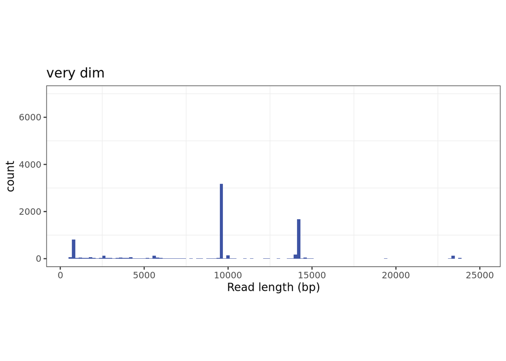

```r
# Plot

OTX2.LCR.read.length.very.dim.plot <- OTX2.LCR.read.length.df %>% filter(read.length >= 400 & read.length <= 25000) %>%
  filter(sample.id == "very_dim") %>%
  ggplot(aes(x=read.length)) +
  geom_histogram(binwidth=200, fill="#3E54A4") + ggtitle("very dim") + xlab("Read length (bp)") + xlim(400, 25000) + ylim(0,7000) +
  theme_bw() + theme(aspect.ratio=0.4, panel.grid.major = element_blank())
OTX2.LCR.read.length.very.dim.plot
```

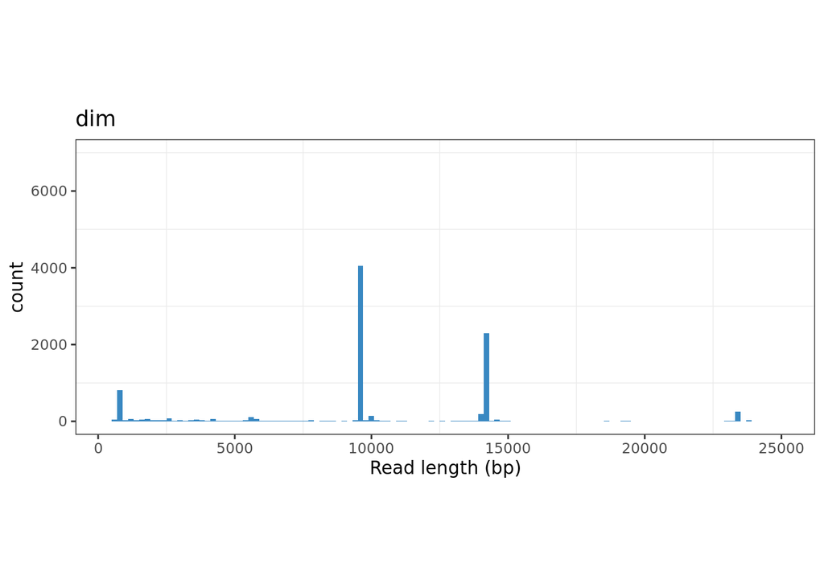

```r
OTX2.LCR.read.length.dim.plot <- OTX2.LCR.read.length.df %>% filter(read.length >= 400 & read.length <= 25000) %>%
  filter(sample.id == "dim") %>%
  ggplot(aes(x=read.length)) +
  geom_histogram(binwidth=200, fill="#3988C2") + ggtitle("dim") + xlab("Read length (bp)") + xlim(400, 25000) + ylim(0,7000) +
  theme_bw() + theme(aspect.ratio=0.4, panel.grid.major = element_blank())
OTX2.LCR.read.length.dim.plot
```

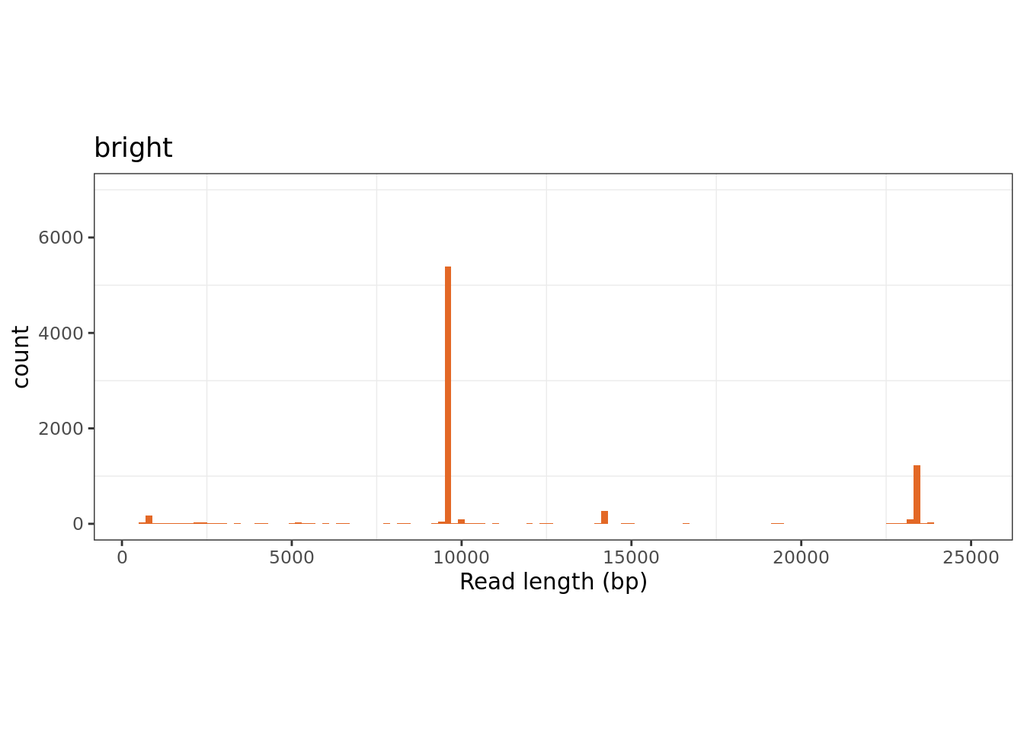

```r
OTX2.LCR.read.length.bright.plot <- OTX2.LCR.read.length.df %>% filter(read.length >= 400 & read.length <= 25000) %>%
  filter(sample.id == "bright") %>%
  ggplot(aes(x=read.length)) +
  geom_histogram(binwidth=200, fill="#E36826") + ggtitle("bright") + xlab("Read length (bp)") + xlim(400, 25000) + ylim(0,7000) +
  theme_bw() + theme(aspect.ratio=0.4, panel.grid.major = element_blank())
OTX2.LCR.read.length.bright.plot
```

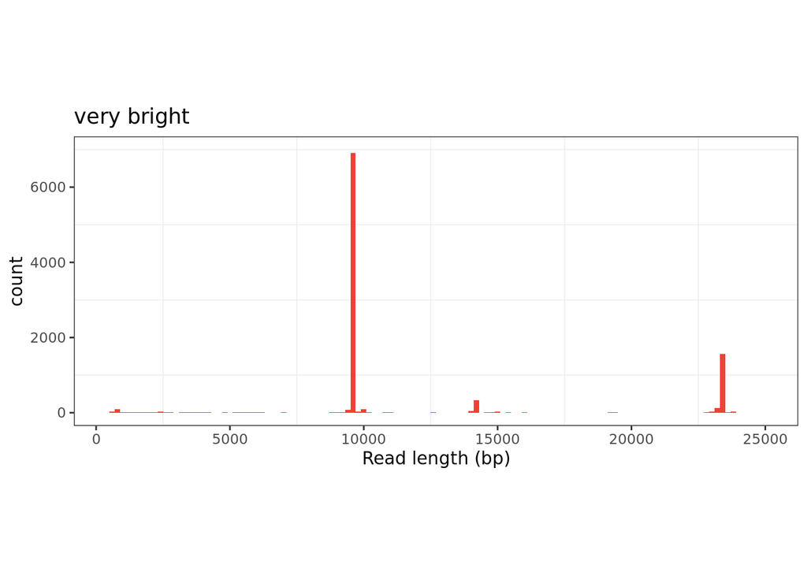

```r
OTX2.LCR.read.length.very.bright.plot <- OTX2.LCR.read.length.df %>% filter(read.length >= 400 & read.length <= 25000) %>%
  filter(sample.id == "very_bright") %>%
  ggplot(aes(x=read.length)) +
  geom_histogram(binwidth=200, fill="#EF4136") + ggtitle("very bright") + xlab("Read length (bp)") + xlim(400, 25000) + ylim(0,7000) +
  theme_bw() + theme(aspect.ratio=0.4, panel.grid.major = element_blank())
OTX2.LCR.read.length.very.bright.plot
```

```r
pdf("./Notebook/Rplots/OTX2/OTX2_LCR_scramble_read_length_distribution.pdf", width=4, height=8, useDingbats=FALSE)
ggarrange(OTX2.LCR.read.length.very.dim.plot, OTX2.LCR.read.length.dim.plot, OTX2.LCR.read.length.bright.plot, OTX2.LCR.read.length.very.bright.plot, nrow = 4)
dev.off()
```

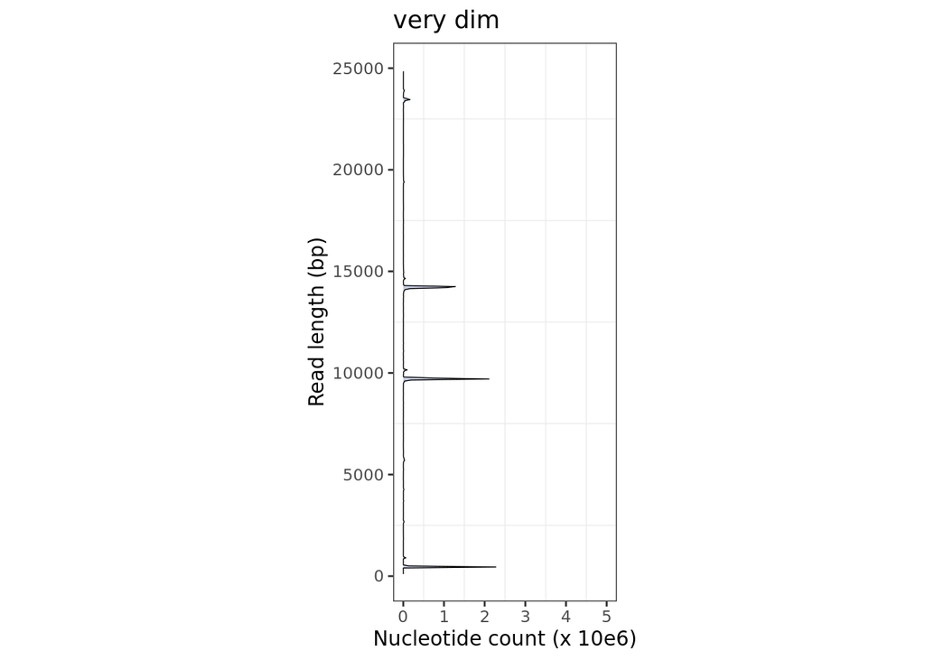

```r
# Transform read count into nucleotide count (res = 200 nt)

OTX2.LCR.nuc.count.df <- OTX2.LCR.read.length.df %>% mutate(ints = (as.numeric(cut(read.length, seq(0, 25000, 50), include.lowest = TRUE, right = FALSE))*50)+50) %>%
  drop_na() %>% group_by(sample.id, ints) %>% summarise(ints = mean(ints, na.rm = T), read.count = dplyr::n()) %>% mutate(nuc.count = read.count*ints)

# Plot

OTX2.LCR.nuc.count.very.dim.plot <- OTX2.LCR.nuc.count.df %>%
  filter(sample.id == "very_dim") %>%
  ggplot(aes(x=ints, y=nuc.count/10e6)) +
  geom_ribbon(aes(ymin = 0, ymax = nuc.count/10e6), fill = "#3E54A4", alpha=0.3, position = "identity") +
  geom_line(linewidth = 0.25) + ylim(0,5) + xlim(0,25000) +
  xlab("Read length (bp)") + ylab("Nucleotide count (x 10e6)") + ggtitle("very dim") +
  theme_bw() + theme(aspect.ratio=2.5, panel.grid.major = element_blank()) + coord_flip()
OTX2.LCR.nuc.count.very.dim.plot
```

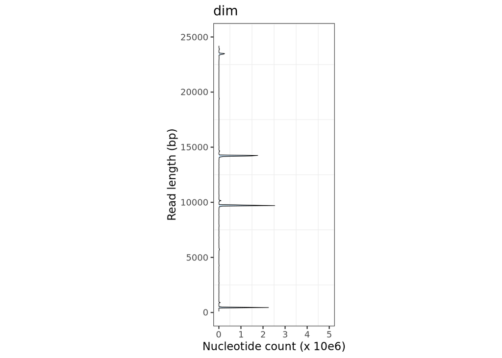

```r
OTX2.LCR.nuc.count.dim.plot <- OTX2.LCR.nuc.count.df %>%
  filter(sample.id == "dim") %>%
  ggplot(aes(x=ints, y=nuc.count/10e6)) +
  geom_ribbon(aes(ymin = 0, ymax = nuc.count/10e6), fill = "#3988C2", alpha=0.3, position = "identity") +
  geom_line(linewidth = 0.25) + ylim(0,5) + xlim(0,25000) +
  xlab("Read length (bp)") + ylab("Nucleotide count (x 10e6)") + ggtitle("dim") +
  theme_bw() + theme(aspect.ratio=2.5, panel.grid.major = element_blank()) + coord_flip()
OTX2.LCR.nuc.count.dim.plot
```

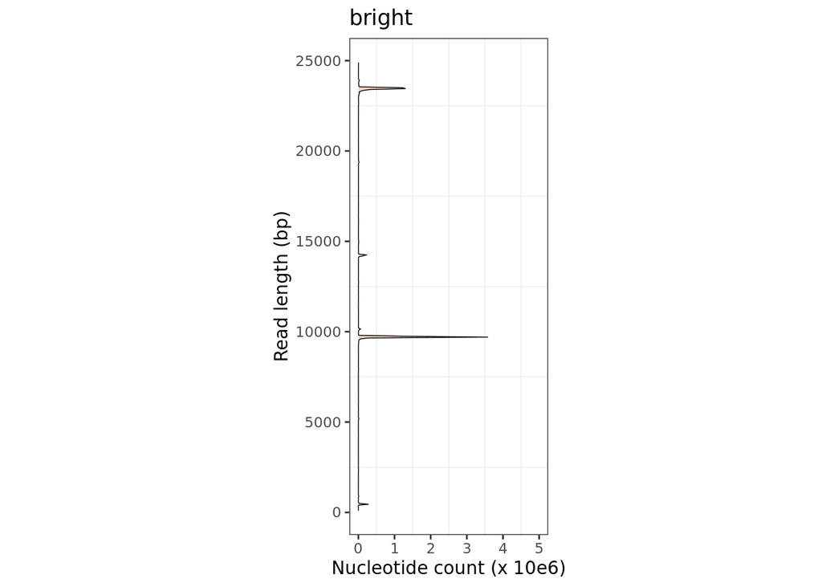

```r
OTX2.LCR.nuc.count.bright.plot <- OTX2.LCR.nuc.count.df %>%
  filter(sample.id == "bright") %>%
  ggplot(aes(x=ints, y=nuc.count/10e6)) +
  geom_ribbon(aes(ymin = 0, ymax = nuc.count/10e6), fill = "#E36826", alpha=0.3, position = "identity") +
  geom_line(linewidth = 0.25) + ylim(0,5) + xlim(0,25000) +
  xlab("Read length (bp)") + ylab("Nucleotide count (x 10e6)") + ggtitle("bright") +
  theme_bw() + theme(aspect.ratio=2.5, panel.grid.major = element_blank()) + coord_flip()
OTX2.LCR.nuc.count.bright.plot
```

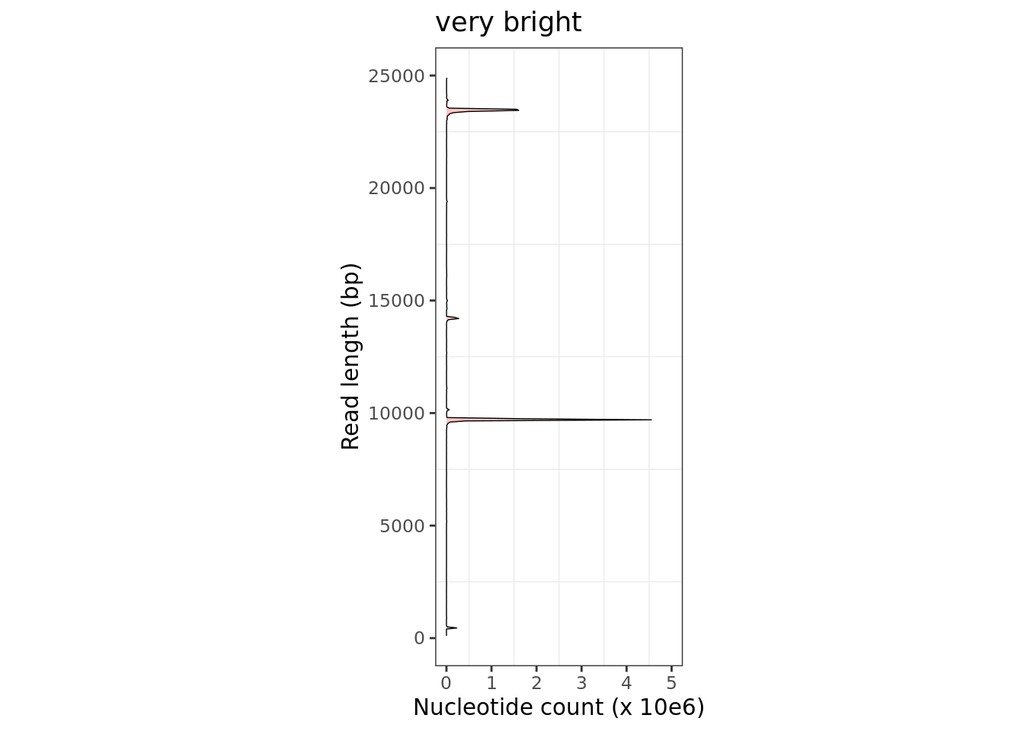

```r
OTX2.LCR.nuc.count.very.bright.plot <- OTX2.LCR.nuc.count.df %>%
  filter(sample.id == "very_bright") %>%
  ggplot(aes(x=ints, y=nuc.count/10e6)) +
  geom_ribbon(aes(ymin = 0, ymax = nuc.count/10e6), fill = "#EF4136", alpha=0.3, position = "identity") +
  geom_line(linewidth = 0.25) + ylim(0,5) + xlim(0,25000) +
  xlab("Read length (bp)") + ylab("Nucleotide count (x 10e6)") + ggtitle("very bright") +
  theme_bw() + theme(aspect.ratio=2.5, panel.grid.major = element_blank()) + coord_flip()
OTX2.LCR.nuc.count.very.bright.plot
```

```r
pdf("./Notebook/Rplots/OTX2/OTX2_LCR_scramble_read_length_distribution_nuc_count.pdf", width=8, height=4, useDingbats=FALSE)
ggarrange(OTX2.LCR.nuc.count.very.dim.plot, OTX2.LCR.nuc.count.dim.plot, OTX2.LCR.nuc.count.bright.plot, OTX2.LCR.nuc.count.very.bright.plot, nrow = 1, ncol = 4)
dev.off()
```

```r
#scp -r farm:/lustre/scratch126/gengen/projects/escramble/Notebook/Rplots/OTX2 /Users/pm23/Desktop/Projects/EnhancerScramble/Rplots
```

# 4 Alignment

Reads are aligned using bwa mem

```bash
# FARM

cd /lustre/scratch126/gengen/projects/escramble/Data/ONT/240408

# Align
bsub -q normal -n 12 -R'select[mem>32000] rusage[mem=32000] span[hosts=1]' -M32000 -o ./SAM/bwa_mem.log -J bwa \
'bwa mem -x ont2d -t 12 /lustre/scratch126/gengen/teams/parts/pm23/Genomes/hg38/hg38.fa.gz ./FASTQ/OTX2_LCR_scramble_all_reads.fastq \
> ./SAM/OTX2_LCR_scramble_all_reads.sam
samtools sort -@ 12 -m 2G ./SAM/OTX2_LCR_scramble_all_reads.sam -o ./BAM/OTX2_LCR_scramble_all_reads.bam
samtools index -@ 12 ./BAM/OTX2_LCR_scramble_all_reads.bam'
```

# 5 Structural variant calling

Call structural variants with Savana (https://github.com/cortes-ciriano-lab/savana). Use a custom installation from Jonas Koeppel. Use a sequenced HAP1 WT as “normal” sample and the scramble clones as “tumour”.

```bash
# FARM

cd /lustre/scratch126/gengen/projects/escramble/Data/ONT/240408

bsub -q normal -n 12 -R'select[mem>100000] rusage[mem=100000] span[hosts=1]' -M 100000 -o ./vcf/savana.log -J savana \
'source /lustre/scratch123/hgi/projects/genome_scramble/software/miniconda3/etc/profile.d/conda.sh
conda activate py310
savana run --depth 5 --threads 12 \
--tumour ./BAM/OTX2_LCR_scramble_all_reads.bam \
--normal /lustre/scratch123/hgi/projects/genome_scramble/genome_scramble_submission/genome_sequencing/bam/HAP1.bam \
--outdir ./vcf/OTX2_LCR_scramble_all_SVs \
--ref /lustre/scratch126/gengen/teams/parts/pm23/Genomes/hg38/hg38.fa'
```

# 6 Structural variants characterisation and analysis

This chunk performs: - Load and format savana vcf files - Call SVs - Format SV data

```r
library(forcats)

setwd("/lustre/scratch126/gengen/projects/escramble/Notebook/")

source("./Scripts/SV.call.LCR.r")

# Define path to savana analysis results
LCR.scramble.path.vcf <- "/lustre/scratch126/gengen/projects/escramble/Data/ONT/240408/vcf/OTX2_LCR_scramble_all_SVs/OTX2_LCR_scramble_all_reads.sv_breakpoints.vcf"
LCR.scramble.path.tsv <- "/lustre/scratch126/gengen/projects/escramble/Data/ONT/240408/vcf/OTX2_LCR_scramble_all_SVs/OTX2_LCR_scramble_all_reads.sv_breakpoints_read_support.tsv"

# Call SVs
LCR.scramble.savana.genotype.df <- OTX2.SV.call.savana(LCR.scramble.path.vcf, LCR.scramble.path.tsv)

# Save raw table
saveRDS(LCR.scramble.savana.genotype.df, "/lustre/scratch126/gengen/projects/escramble/Notebook/004_OTX2_LCR_scramble/rds/LCR.scramble.savana.genotype.df.rds")

# Format SV events - we filter for read mapped to our sample
all.savana.LCR.read.length.df <- readRDS("/lustre/scratch126/gengen/projects/escramble/Notebook/004_OTX2_LCR_scramble/rds/OTX2.LCR.read.length.df.rds")

LCR.scramble.savana.genotype.read.summary.df <- LCR.scramble.savana.genotype.df %>% filter(read_names %in% all.savana.LCR.read.length.df$read.id) %>% group_by(read_names) %>% summarise(genotype = paste0(genotype, collapse = "-"), ) %>%
    group_by(genotype) %>% summarise(supp_reads = dplyr::n(), read_names = paste0(read_names, collapse = "_")) %>% filter(!grepl("DUP", genotype)) %>% arrange(-supp_reads)

# Save processed table
saveRDS(LCR.scramble.savana.genotype.read.summary.df, "/lustre/scratch126/gengen/projects/escramble/Notebook/004_OTX2_LCR_scramble/rds/LCR.scramble.savana.genotype.read.summary.df.rds")
```

# 7 Coverage plots

Prepare coverage plots of SVs for QC and visualisation File formarting is reported in the supporting R code: /lustre/scratch126/gengen/projects/escramble/Notebook/004_OTX2_LCR_scramble_supporting_codes.R

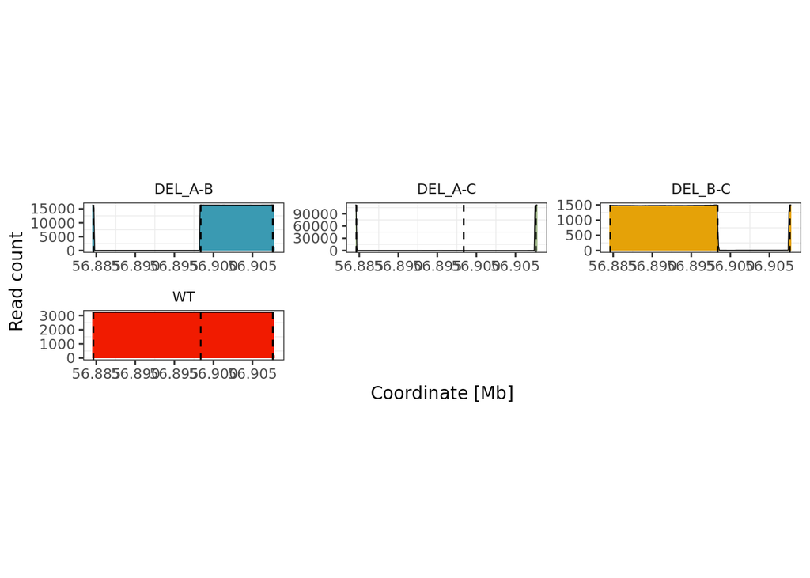

```r
library(dplyr)
library(tidyr)
library(ggplot2)
library(forcats)
library(wesanderson)
library(ggpubr)

setwd("/lustre/scratch126/gengen/projects/escramble/Notebook/")

# Define region to plot
chr <- "chr14"
from <- 56884500
to <- 56907900

# Load data
LCR.savana.deletion.coverage.df <- readRDS("/lustre/scratch126/gengen/projects/escramble/Notebook/004_OTX2_LCR_scramble/rds/LCR.savana.deletion.coverage.df.rds")
LCR.savana.inversion.coverage.df <- readRDS("/lustre/scratch126/gengen/projects/escramble/Notebook/004_OTX2_LCR_scramble/rds/LCR.savana.inversion.coverage.df.rds")

# Deletion

LCR.deletion.palette <- wes_palette("Zissou1", length(unique(LCR.savana.deletion.coverage.df$variant)), type = "continuous")
LCR.savana.deletion.coverage.plot <- LCR.savana.deletion.coverage.df %>% ggplot(aes(x = start/1e6, y = score, group=1, fill = variant)) +
  geom_area() +
  geom_line(col = "black", linewidth = 0.25) +
  ylab("Read count") + xlab("Coordinate [Mb]") +
  scale_fill_manual(values=c(LCR.deletion.palette)) +
  xlim(from/1e6, to/1e6) +
  geom_vline(xintercept=56884634/1e6, linetype="dashed") +
  geom_vline(xintercept=56898376/1e6, linetype="dashed") +
  geom_vline(xintercept=56907608/1e6, linetype="dashed") +
  facet_wrap(~ variant, scales = "free", ncol = 3) +
  theme_bw() + theme(aspect.ratio=0.25, panel.grid.major = element_blank(), strip.background = element_blank(), legend.position="none")
LCR.savana.deletion.coverage.plot
```

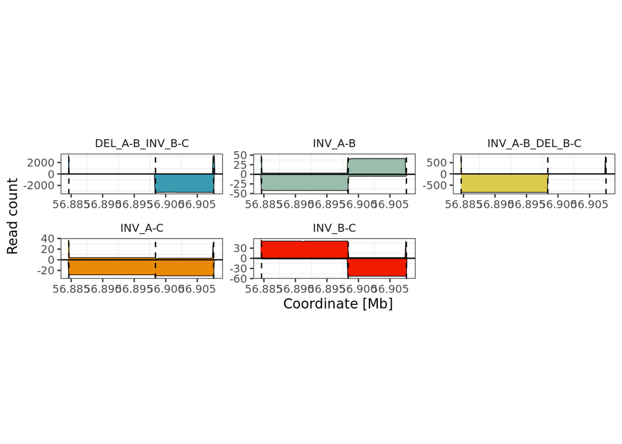

```r
LCR.inversion.palette <- wes_palette("Zissou1", length(unique(LCR.savana.inversion.coverage.df$variant)), type = "continuous")
LCR.savana.inversion.coverage.plot <- LCR.savana.inversion.coverage.df %>% ggplot(aes(x = start/1e6, y = score, group=1, fill = variant)) +
  geom_area(aes(group = strand)) +
  geom_line(aes(group = strand), col = "black", linewidth = 0.25) +
  ylab("Read count") + xlab("Coordinate [Mb]") +
  scale_fill_manual(values=c(LCR.inversion.palette)) +
  xlim(from/1e6, to/1e6) +
  geom_hline(yintercept=0, linetype="solid") +
  geom_vline(xintercept=56884634/1e6, linetype="dashed") +
  geom_vline(xintercept=56898376/1e6, linetype="dashed") +
  geom_vline(xintercept=56907608/1e6, linetype="dashed") +
  facet_wrap(~ variant, scales = "free", ncol = 3) +
  theme_bw() + theme(aspect.ratio=0.25, panel.grid.major = element_blank(), strip.background = element_blank(), legend.position="none")
LCR.savana.inversion.coverage.plot
```

```r
pdf("./Rplots/OTX2/coverage.LCR.deletion.pdf", width=10, height=10, useDingbats=FALSE)
LCR.savana.deletion.coverage.plot
dev.off()
```

```r
pdf("./Rplots/OTX2/coverage.LCR.inversion.pdf", width=10, height=10, useDingbats=FALSE)
LCR.savana.inversion.coverage.plot
dev.off()
```

```r
#scp -r farm:/lustre/scratch126/gengen/projects/escramble/Notebook/Rplots/OTX2 /Users/pm23/Desktop/Projects/EnhancerScramble/Rplots
```

# 8 Effect on gene expression

Prepare gene expression [sorting gates] plots of SVs File formarting and computation is reported in the supporting R code: /lustre/scratch126/gengen/projects/escramble/Notebook/004_OTX2_LCR_scramble_supporting_codes.R

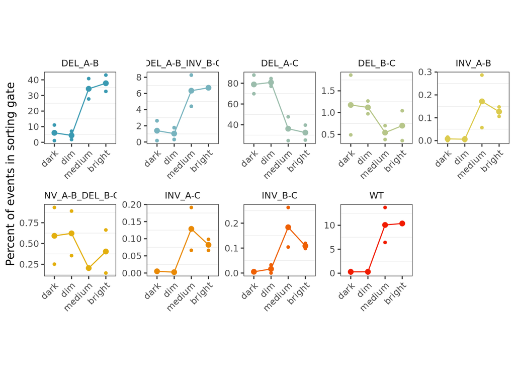

```r
library(dplyr)
library(tidyr)
library(ggplot2)
library(forcats)
library(wesanderson)
library(ggpubr)

setwd("/lustre/scratch126/gengen/projects/escramble/Notebook/")

# Load results

LCR.savana.SV.summary <- readRDS("/lustre/scratch126/gengen/projects/escramble/Notebook/004_OTX2_LCR_scramble/rds/LCR.savana.SV.summary.rds")

LCR.savana.SV.summary.clean.df <- LCR.savana.SV.summary %>%
  dplyr::select(genotype, replicate = rep, gate = sample, read_count = count, read_percentage = perc) %>%
  mutate(gate = case_when(gate == "very_dim" ~ "dark",
                          gate == "dim" ~ "dim",
                          gate == "bright" ~ "medium",
                          gate == "very_bright" ~ "bright")) %>%
  mutate(read_count = replace_na(read_count, 0)) %>% arrange(genotype)
write.table(LCR.savana.SV.summary.clean.df, "./Summary/OTX2/loxPsym.3.clonal.PCR.summary.tsv", sep="\t", col.names = T, row.names = F, quote = F)

# Prepare plots

LCR.palette <- wes_palette("Zissou1", length(unique(LCR.savana.SV.summary$genotype)), type = "continuous")
LCR.savana.SV.plot <- LCR.savana.SV.summary %>%
  mutate(sample = case_when(sample == "very_dim" ~ "dark", sample == "dim" ~ "dim", sample == "bright" ~ "medium", sample == "very_bright" ~ "bright")) %>%
  mutate(SAMPLE = fct_relevel(sample, "dark", "dim", "medium", "bright")) %>%
  ggplot(aes(x=SAMPLE, y=perc, group=1, col = genotype)) +
  geom_point(aes(x = SAMPLE, y = perc), size = 1) +
  geom_point(stat='summary', fun.y=sum, size = 2) +
  geom_line(stat='summary', fun.y=sum) +
  ylab("Percent of events in sorting gate") +
  scale_colour_manual(values=c(LCR.palette)) +
  facet_wrap(~ genotype, scales = "free", ncol = 5) +
  theme_bw() + theme(aspect.ratio=1, strip.background = element_blank(), panel.grid.major = element_blank(), axis.title.x=element_blank(), axis.text.x = element_text(angle = 45, vjust = 1, hjust=1), legend.position="none")
LCR.savana.SV.plot
```

```r
pdf("./Rplots/OTX2/savana.LCR.gate.plot.pdf", width=10, height=10, useDingbats=FALSE)
LCR.savana.SV.plot
dev.off()
```

```r
#scp -r farm:/lustre/scratch126/gengen/projects/escramble/Notebook/Rplots/OTX2 /Users/pm23/Desktop/Projects/EnhancerScramble/Rplots
```

Compute gene expression score

```r
# Load results

LCR.savana.SV.summary <- readRDS("/lustre/scratch126/gengen/projects/escramble/Notebook/004_OTX2_LCR_scramble/rds/LCR.savana.SV.summary.rds")

LCR.savana.SV.gene.exp.score.df <- LCR.savana.SV.summary %>%
  group_by(genotype, rep) %>%
  mutate(scale = perc/sum(perc)) %>% drop_na() %>%
  dplyr::select(genotype, sample, rep, scale) %>% ungroup() %>% distinct() %>%
  pivot_wider(names_from = sample, values_from = scale) %>%
  mutate(across(where(is.numeric), ~replace_na(., 0))) %>%
  mutate(score = (-1*very_dim)+(-0.5*dim)+(0.5*bright)+(1*very_bright))

# Sacle to WT and full deletion

LCR.savana.SV.score.means.df <- LCR.savana.SV.gene.exp.score.df %>% group_by(genotype) %>% summarise(mean=mean(score, na.rm = T))
# WT = 0.721, DEL_A-C = -0.307
LCR.savana.SV.gene.exp.score.df <- LCR.savana.SV.gene.exp.score.df %>% mutate(score.norm = ((score+0.307)/(0.721+0.307))*100)
saveRDS(LCR.savana.SV.gene.exp.score.df, "/lustre/scratch126/gengen/projects/escramble/Notebook/004_OTX2_LCR_scramble/rds/LCR.savana.SV.gene.exp.score.df.rds")
```

# 9 Comparision to cas9 enrichment approach

This chuncks aim to compare the long-range PCR ans cas9 enrichment by comparing the representation of structural variants detected using either of the apporach. Analysis of the LCR cas9 enrichment experiments is provided in /lustre/scratch126/gengen/projects/escramble/Notebook/003_OTX2_superenhancer_scramble_reanalysis_v1_1.Rmd

Compare the representation of SV, read coverage and relative gene expression score from both approach

```r
# R

##############################################################################
# Load results

# Raw observations

# PCR
PCR.SV.LCR.df <- readRDS("/lustre/scratch126/gengen/projects/escramble/Notebook/004_OTX2_LCR_scramble/rds/LCR.savana.SV.summary.rds")

# cas9
cas9.SV.df <- read.table("/lustre/scratch126/gengen/projects/escramble/Data/JK_data/summary_table/OTX2_scramble_outcomes.tsv", sep = "\t", header = T)
cas9.SV.LCR.df <- cas9.SV.df %>% filter(experiment == "3_loxPsym_clone")
# 9 SVs

# Gene expression scores

# PCR
PCR.gene.exp.score.LCR.df <- readRDS("/lustre/scratch126/gengen/projects/escramble/Notebook/004_OTX2_LCR_scramble/rds/LCR.savana.SV.gene.exp.score.df.rds")

# cas9
cas9.gene.exp.score.LCR.df <- readRDS("/lustre/scratch126/gengen/projects/escramble/Notebook/004_OTX2_LCR_scramble/rds/SV.3.loxPsym.cas9.SV.score.df.rds")


##############################################################################
# Reformat table for comparision

# Define variant name

unique(cas9.SV.LCR.df$variant_name)
# "∆R4"      "iR4"      "∆R45"     "iR45"     "∆R5"
# "iR5"      "∆R4+iR5"  "wildtype" "iR4+∆R5"

unique(PCR.SV.LCR.df$genotype)
# "WT"              "DEL_A-C"         "DEL_A-B"
# "DEL_B-C"         "INV_A-C"         "INV_A-B"
# "INV_B-C"         "DEL_A-B_INV_B-C" "INV_A-B_DEL_B-C"

# Reformat and combine

# Bind data
PCR.SV.LCR.format.df <- PCR.SV.LCR.df %>% mutate(genotype = case_when(genotype == "WT" ~ "wildtype",
                                                               genotype == "DEL_A-C" ~ "∆R45",
                                                               genotype == "DEL_A-B" ~ "∆R4",
                                                               genotype == "DEL_B-C" ~ "∆R5",
                                                               genotype == "INV_A-C" ~ "iR45",
                                                               genotype == "INV_A-B" ~ "iR4",
                                                               genotype == "INV_B-C" ~ "iR5",
                                                               genotype == "DEL_A-B_INV_B-C" ~ "∆R4+iR5",
                                                               genotype == "INV_A-B_DEL_B-C" ~ "iR4+∆R5")) %>%
                                          mutate(sample = case_when(sample == "very_dim" ~ "dark",
                                                                    sample == "dim" ~ "dim",
                                                                    sample == "bright" ~ "medium",
                                                                    sample == "very_bright" ~ "bright")) %>%
  dplyr::select(variant_name = genotype, gate = sample, replicate = rep, supp_reads = count, perc_reads = perc) %>% mutate(experiment = "PCR")
cas9.SV.LCR.format.df <- cas9.SV.LCR.df  %>%
  dplyr::select(variant_name, gate, replicate, supp_reads, perc_reads) %>% mutate(experiment = "cas9")
SV.LCR.summary.bind.df <- rbind(PCR.SV.LCR.format.df, cas9.SV.LCR.format.df)
saveRDS(SV.LCR.summary.bind.df, "/lustre/scratch126/gengen/projects/escramble/Notebook/004_OTX2_LCR_scramble/rds/SV.LCR.summary.bind.df.rds")

# Join data

PCR.SV.LCR.format.2.df <- PCR.SV.LCR.format.df %>% group_by(variant_name, gate) %>%
  summarise(supp_reads_sum_PCR = sum(supp_reads, na.rm = T))
cas9.SV.LCR.format.2.df <- cas9.SV.LCR.format.df %>% group_by(variant_name, gate) %>%
  summarise(supp_reads_sum_cas9 = sum(supp_reads, na.rm = T))
SV.LCR.summary.join.df <- PCR.SV.LCR.format.2.df %>% left_join(cas9.SV.LCR.format.2.df, by = c("variant_name", "gate"))
saveRDS(SV.LCR.summary.join.df, "/lustre/scratch126/gengen/projects/escramble/Notebook/004_OTX2_LCR_scramble/rds/SV.LCR.summary.join.df.rds")

# Gene expression scores

PCR.gene.exp.score.LCR.format.df <- PCR.gene.exp.score.LCR.df %>%
  mutate(
    genotype = case_when(
      genotype == "WT" ~ "wildtype",
      genotype == "DEL_A-C" ~ "∆R45",
      genotype == "DEL_A-B" ~ "∆R4",
      genotype == "DEL_B-C" ~ "∆R5",
      genotype == "INV_A-C" ~ "iR45",
      genotype == "INV_A-B" ~ "iR4",
      genotype == "INV_B-C" ~ "iR5",
      genotype == "DEL_A-B_INV_B-C" ~ "∆R4+iR5",
      genotype == "INV_A-B_DEL_B-C" ~ "iR4+∆R5"
    )
  ) %>%
  dplyr::select(variant_name = genotype, replicate = rep, score.PCR = score.norm) %>%
  group_by(variant_name) %>%
  summarise(
    score.PCR.mean = mean(score.PCR, na.rm = TRUE),
    score.PCR.diff = abs(score.PCR.mean - score.PCR)
  ) %>%
  ungroup() %>%
  distinct(variant_name, score.PCR.mean, .keep_all = TRUE)

cas9.gene.exp.score.LCR.format.df <- cas9.gene.exp.score.LCR.df %>%
  dplyr::select(variant_name, replicate, score.cas9 = score.norm) %>% group_by(variant_name) %>%
  summarise(
    score.cas9.mean = mean(score.cas9, na.rm = TRUE),
    score.cas9.diff = abs(score.cas9.mean - score.cas9)
  ) %>%
  ungroup() %>%
  distinct(variant_name, score.cas9.mean, .keep_all = TRUE)

gene.exp.score.LCR.comp.df <- PCR.gene.exp.score.LCR.format.df %>% left_join(cas9.gene.exp.score.LCR.format.df, by = "variant_name") %>% ungroup() %>% distinct()
saveRDS(gene.exp.score.LCR.comp.df, "/lustre/scratch126/gengen/projects/escramble/Notebook/004_OTX2_LCR_scramble/rds/gene.exp.score.LCR.comp.df.rds")
```

Plot results

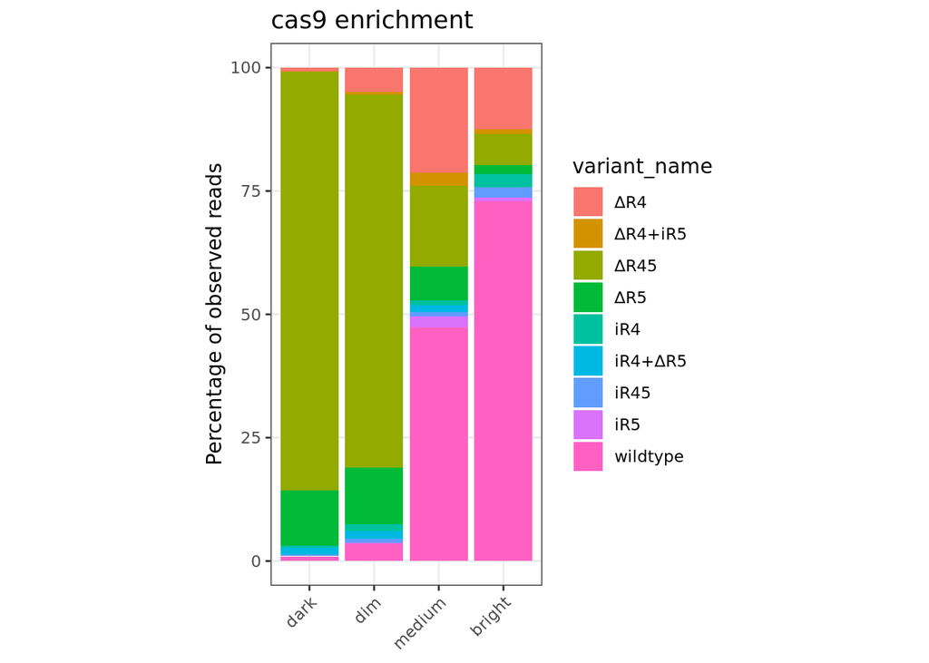

```r
library(dplyr)
library(tidyr)
library(ggplot2)
library(forcats)
library(scales)
library(ggpubr)

setwd("/lustre/scratch126/gengen/projects/escramble")

# SV diversity

SV.LCR.summary.bind.df <- readRDS("/lustre/scratch126/gengen/projects/escramble/Notebook/004_OTX2_LCR_scramble/rds/SV.LCR.summary.bind.df.rds")

SV.div.cas9.plot <- SV.LCR.summary.bind.df %>% filter(experiment == "cas9") %>% group_by(variant_name, gate) %>% summarise(perc_reads = mean(perc_reads, na.rm = T)) %>% ungroup() %>%
  group_by(gate) %>% mutate(perc_reads_scaled = perc_reads / sum(perc_reads) * 100) %>% ungroup() %>%
  mutate(GATE = fct_relevel(gate, "dark", "dim", "medium", "bright")) %>%
  ggplot(aes(x=GATE, y=perc_reads_scaled, fill=variant_name)) +
  geom_bar(stat="identity") + ylab("Percentage of observed reads") + ggtitle("cas9 enrichment") +
  theme_bw() + theme(aspect.ratio=2, panel.grid.minor = element_blank(), axis.title.x=element_blank(), axis.text.x = element_text(angle = 45, vjust = 1, hjust=1))
SV.div.cas9.plot
```

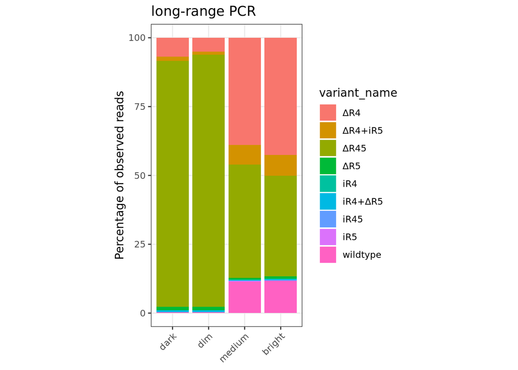

```r
SV.div.PCR.plot <- SV.LCR.summary.bind.df %>% filter(experiment == "PCR") %>% group_by(variant_name, gate) %>% summarise(perc_reads = mean(perc_reads, na.rm = T)) %>% ungroup() %>%
  group_by(gate) %>% mutate(perc_reads_scaled = perc_reads / sum(perc_reads) * 100) %>% ungroup() %>%
  mutate(GATE = fct_relevel(gate, "dark", "dim", "medium", "bright")) %>%
  ggplot(aes(x=GATE, y=perc_reads_scaled, fill=variant_name)) +
  geom_bar(stat="identity") + ylab("Percentage of observed reads") + ggtitle("long-range PCR") +
  theme_bw() + theme(aspect.ratio=2, panel.grid.minor = element_blank(), axis.title.x=element_blank(), axis.text.x = element_text(angle = 45, vjust = 1, hjust=1))
SV.div.PCR.plot
```

```r
# Read count corelation

SV.LCR.summary.join.df <- readRDS("/lustre/scratch126/gengen/projects/escramble/Notebook/004_OTX2_LCR_scramble/rds/SV.LCR.summary.join.df.rds")
# Compute corelation
cor.test(log10(SV.LCR.summary.join.df$supp_reads_sum_cas9), log10(SV.LCR.summary.join.df$supp_reads_sum_PCR), method = "spearman")
```

```
##
##  Spearman's rank correlation rho
##
## data:  log10(SV.LCR.summary.join.df$supp_reads_sum_cas9) and log10(SV.LCR.summary.join.df$supp_reads_sum_PCR)
## S = 2670.2, p-value = 0.0002258
## alternative hypothesis: true rho is not equal to 0
## sample estimates:
##       rho
## 0.5920263
```

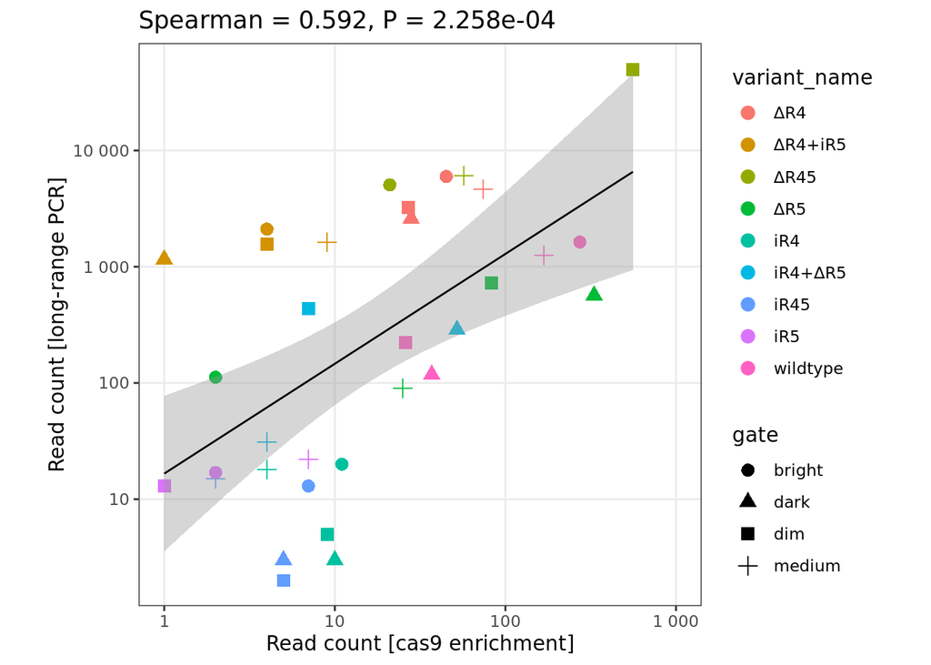

```r
# Plot
SV.read.cor.plot <- SV.LCR.summary.join.df %>% ggplot(aes(x=supp_reads_sum_cas9, y=supp_reads_sum_PCR, color = variant_name, shape = gate)) +
  geom_point(size = 3) + scale_x_log10(labels = label_number(), limits = c(1,1000)) + scale_y_log10(labels = label_number()) +
  geom_smooth(aes(group = 1), method = "lm", se = T, color = "black", size = 0.5) +
  xlab("Read count [cas9 enrichment]") + ylab("Read count [long-range PCR]") + ggtitle("Spearman = 0.592, P = 2.258e-04") +
  theme_bw() + theme(aspect.ratio=1, panel.grid.minor = element_blank())
SV.read.cor.plot
```

```r
summary(SV.LCR.summary.join.df$supp_reads_sum_PCR/SV.LCR.summary.join.df$supp_reads_sum_cas9)
```

```
##     Min.  1st Qu.   Median     Mean  3rd Qu.     Max.     NA's
##    0.300    3.292    8.539   98.080   91.761 1160.000        2
```

```r
# Gene expression score corelation

gene.exp.score.LCR.comp.df <- readRDS("/lustre/scratch126/gengen/projects/escramble/Notebook/004_OTX2_LCR_scramble/rds/gene.exp.score.LCR.comp.df.rds")

# Compute corelation
cor.test(gene.exp.score.LCR.comp.df$score.PCR.mean, gene.exp.score.LCR.comp.df$score.cas9.mean, method = "spearman")
```

```
##
##  Spearman's rank correlation rho
##
## data:  gene.exp.score.LCR.comp.df$score.PCR.mean and gene.exp.score.LCR.comp.df$score.cas9.mean
## S = 34, p-value = 0.03687
## alternative hypothesis: true rho is not equal to 0
## sample estimates:
##       rho
## 0.7166667
```

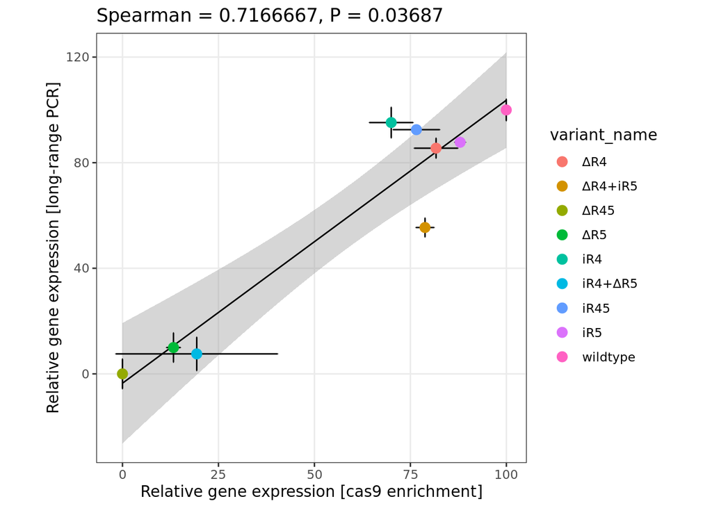

```r
# Plot
gene.exp.score.LCR.comp.plot <- gene.exp.score.LCR.comp.df %>% ggplot(aes(x = score.cas9.mean, y = score.PCR.mean, color = variant_name)) +
  geom_smooth(aes(group = 1), method = "lm", se = T, color = "black", size = 0.5) +
  geom_errorbar(aes(ymin = score.PCR.mean-score.PCR.diff, ymax = score.PCR.mean+score.PCR.diff), width = 0.2, color = "black") +
  geom_errorbarh(aes(xmin = score.cas9.mean-score.cas9.diff, xmax = score.cas9.mean+score.cas9.diff), height = 0.2, color = "black") +
  geom_point(size = 3) +
  xlab("Relative gene expression [cas9 enrichment]") + ylab("Relative gene expression [long-range PCR]") + ggtitle("Spearman = 0.7166667, P = 0.03687") +
  theme_bw() + theme(aspect.ratio=1, panel.grid.minor = element_blank())
gene.exp.score.LCR.comp.plot
```

```r
pdf("./Notebook/Rplots/OTX2/Comp_PCR_cas9_part_1.pdf", width=6, height=4, useDingbats=FALSE)
ggarrange(SV.div.cas9.plot, SV.div.PCR.plot, nrow = 1)
dev.off()
```

```r
pdf("./Notebook/Rplots/OTX2/Comp_PCR_cas9_part_2.pdf", width=10, height=4, useDingbats=FALSE)
ggarrange(SV.read.cor.plot, gene.exp.score.LCR.comp.plot, nrow = 1)
dev.off()
```